# Final project: Practical Machine Learning

### Jose L. Rolando, May 2017

## Summary

In the present project, a random forest algorithm was used in order to predict qualitative activity of weight lifting exercises. Data from Velloso et al. (2013) data set was used. It consisted of a set of features on the Euler angles, raw accelerometer, gyroscope and magnetometer readings extracted from sensors placed on user’s gloves, armbands, lumbar belt and dumbbell. Variables with a high amount of missing values, as well as two outlier observations were removed. The fitted model had a accuracy of 99.46%. Based on this results, we conclude that fitting a random forest to the sensors raw data is enough in order to predict the quality of a weight lifting exercise.

## Getting and cleaning data

Load libraries, and download the training and test dataset.

```r
#libraries
library(ggplot2)
library(reshape2)
library(caret)
library(randomForest)
library(ggthemes)
#DOWNLOAD FILES
destfile1 <- './pml-training.csv'
if (!file.exists(destfile1))
      {
      download.file("https://d396qusza40orc.cloudfront.net/predmachlearn/pml-training.csv", "./pml-training.csv")
}

destfile2 <- "./pml-testing.csv"
if (!file.exists(destfile2))
      {
      download.file("https://d396qusza40orc.cloudfront.net/predmachlearn/pml-testing.csv", "./pml-testing.csv")
}
```

Load the downloaded data frames into R.

```r
#Import data to R
pml<-read.csv("pml-training.csv", header = T, na.strings = c("NA", ""))
test<-read.csv("pml-testing.csv", header = T, na.strings = c("NA", ""))
```

Summary statistics are presented.

```r
summary(pml$classe)
```

```
##    A    B    C    D    E
## 5580 3797 3422 3216 3607
```

```r
summary(pml[,1:15])
```

```
##        X            user_name    raw_timestamp_part_1 raw_timestamp_part_2
##  Min.   :    1   adelmo  :3892   Min.   :1.322e+09    Min.   :   294
##  1st Qu.: 4906   carlitos:3112   1st Qu.:1.323e+09    1st Qu.:252912
##  Median : 9812   charles :3536   Median :1.323e+09    Median :496380
##  Mean   : 9812   eurico  :3070   Mean   :1.323e+09    Mean   :500656
##  3rd Qu.:14717   jeremy  :3402   3rd Qu.:1.323e+09    3rd Qu.:751891
##  Max.   :19622   pedro   :2610   Max.   :1.323e+09    Max.   :998801
##
##           cvtd_timestamp  new_window    num_window      roll_belt
##  28/11/2011 14:14: 1498   no :19216   Min.   :  1.0   Min.   :-28.90
##  05/12/2011 11:24: 1497   yes:  406   1st Qu.:222.0   1st Qu.:  1.10
##  30/11/2011 17:11: 1440               Median :424.0   Median :113.00
##  05/12/2011 11:25: 1425               Mean   :430.6   Mean   : 64.41
##  02/12/2011 14:57: 1380               3rd Qu.:644.0   3rd Qu.:123.00
##  02/12/2011 13:34: 1375               Max.   :864.0   Max.   :162.00
##  (Other)         :11007
##    pitch_belt          yaw_belt       total_accel_belt kurtosis_roll_belt
##  Min.   :-55.8000   Min.   :-180.00   Min.   : 0.00    #DIV/0!  :   10
##  1st Qu.:  1.7600   1st Qu.: -88.30   1st Qu.: 3.00    -1.908453:    2
##  Median :  5.2800   Median : -13.00   Median :17.00    -0.016850:    1
##  Mean   :  0.3053   Mean   : -11.21   Mean   :11.31    -0.021024:    1
##  3rd Qu.: 14.9000   3rd Qu.:  12.90   3rd Qu.:18.00    -0.025513:    1
##  Max.   : 60.3000   Max.   : 179.00   Max.   :29.00    (Other)  :  391
##                                                        NA's     :19216
##  kurtosis_picth_belt kurtosis_yaw_belt skewness_roll_belt
##  #DIV/0!  :   32     #DIV/0!:  406     #DIV/0!  :    9
##  47.000000:    4     NA's   :19216     0.000000 :    4
##  -0.150950:    3                       0.422463 :    2
##  -0.684748:    3                       -0.003095:    1
##  -1.750749:    3                       -0.010002:    1
##  (Other)  :  361                       (Other)  :  389
##  NA's     :19216                       NA's     :19216
```

Since some variables present a great percentage of missing values, we quantified how many observations were missing.

```r
count.NA <- apply(pml, 2, function(x) sum(is.na(x)))
unique(count.NA)
```

```
## [1]     0 19216
```

```r
19216/length(pml$avg_pitch_forearm)
```

```
## [1] 0.9793089
```

The variables with almost 98% of missing values were removed from the dataset.

```r
query.NA <- apply(as.matrix(count.NA), 2, function(x) x == 19216)
pml<- pml[,!query.NA]
test<- test[,!query.NA]
```

The first 7 variables were also removed, since they were related to identifying the observation in user subject, ID, or time variables that are not relevant in order to predict future events in random people and events.

```r
names(pml)[1:7]
```

```
## [1] "X"                    "user_name"            "raw_timestamp_part_1"
## [4] "raw_timestamp_part_2" "cvtd_timestamp"       "new_window"
## [7] "num_window"
```

```r
pml<-pml[,8:60]
test<-test[,8:60]
```

Two outlier observations were removed based on a exploratory analysis not shown in the present report.

```r
pml<-pml[pml$gyros_forearm_y<200 & pml$magnet_dumbbell_y > -3000,]
```

## Exploratory analysis

Having run some cleaning code to the data set, we now present a boxplot of all remaining variables in order confirm the effectiveness of the process.

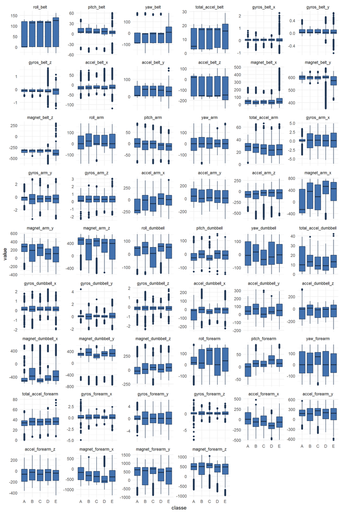

```r
plot_train<-melt(pml, id = "classe")
fill <- "#4271AE"
line <- "#1F3552"
ggplot(plot_train, (aes(x=classe, y=value)))+geom_boxplot(fill = fill, colour = line)+
      facet_wrap(~variable, scales="free_y", ncol=6)+theme_minimal()+
      theme(legend.position = "none")
```

## Machine learning algorithm

The test data set was not used in order to verify the fitted model because the “classe” outcome was not present. Instead, we subsetted the largest data set in two (i.e., training and testing) in order to validate our fitted model correctly, and avoid overfitting.

```r
set.seed(325)

inTrain<-createDataPartition(pml$classe,p=0.7, list=FALSE)
training<-pml[inTrain,]
testing<-pml[-inTrain,]
```

Next, we trained out training data set using the random forest algorithm. We show the confusion matrix of the prediction and actual values from the testing data set.

```r
mod1<-randomForest(classe ~ ., data = training, prox= TRUE)
pred1<-predict(mod1, newdata = testing)
confusionMatrix(pred1,testing$classe)
```

```
## Confusion Matrix and Statistics
##
##           Reference
## Prediction    A    B    C    D    E
##          A 1673    6    0    0    0
##          B    0 1131   13    0    0
##          C    0    1 1013   11    1
##          D    0    0    0  953    0
##          E    0    0    0    0 1081
##
## Overall Statistics
##
##                Accuracy : 0.9946
##                  95% CI : (0.9923, 0.9963)
##     No Information Rate : 0.2844
##     P-Value [Acc > NIR] : < 2.2e-16
##
##                   Kappa : 0.9931
##  Mcnemar's Test P-Value : NA
##
## Statistics by Class:
##
##                      Class: A Class: B Class: C Class: D Class: E
## Sensitivity            1.0000   0.9938   0.9873   0.9886   0.9991
## Specificity            0.9986   0.9973   0.9973   1.0000   1.0000
## Pos Pred Value         0.9964   0.9886   0.9873   1.0000   1.0000
## Neg Pred Value         1.0000   0.9985   0.9973   0.9978   0.9998
## Prevalence             0.2844   0.1934   0.1744   0.1639   0.1839
## Detection Rate         0.2844   0.1922   0.1722   0.1620   0.1837
## Detection Prevalence   0.2854   0.1945   0.1744   0.1620   0.1837
## Balanced Accuracy      0.9993   0.9956   0.9923   0.9943   0.9995
```

The fitted model had a accuracy of 99.46%. Based on this results, we conclude that fitting a random forest to the sensors raw data is enough in order to predict the quality of a weight lifting exercise.